# FY25 Official Forecasting for FY26 Foundation Payment: ETS + Percentage-Based (PCT) Methods

Kristen Mosley

2025-11-12

# 1 Document Summary

This document brings together the two forecasting approaches used by the Coordinating Board to project future student outcomes: the **Exponential Triple Smoothing (ETS) method** and the **Percentage-based (PCT) method**.

It first runs the ETS forecasting process to determine forecasts for student outcomes not defined as high-demand or specified for a student subgroup (e.g., academic disadvantage). **ETS forecasting produces 12 forecast outputs.** Then, it applies the PCT forecasting process to determine high-demand field and student subgroup outcomes. **PCT forecasting produces 63 forecast outputs.**

The final combined forecast outputs, which integrate both methods, are saved in the final-forecasts/ folder for input in the funding model.

A **quality control (QC) process** is built-in throughout the forecasting model to provide plain-language messaging for each step of the process. If any step fails, the process will stop and provide a message indicating the issue. Warnings and informational messages are also provided to track the progress of the model.

# 2 Load Packages

```r
options(width = 999)
knitr::opts_chunk$set(warning = FALSE, cache = FALSE, tidy = FALSE)

# Load necessary packages
library(tidyverse)
library(tsibble)
library(fable)
library(fabletools)
library(knitr)
library(openxlsx)
library(purrr)
library(kableExtra)
library(ggplot2)
library(feasts)
```

# 3 Import, Merge, and Clean Historical Data

```r
# Clean and merge data function
# Reads raw data, merges in OSA/ICLC data, outputs combined Excel, returns tsibble
# Cleans and prepares the dataset for forecasting
# Identifies historical data gaps with "NA"
# @param raw_file Path to raw data Excel file
# @param osa_file Path to OSA Excel file
# @param iclc_file Path to ICLC Excel file
# @param output_file Path to save combined Excel file
# @return Cleaned tsibble ready for forecasting
clean_and_merge_data <- function(
  raw_file = params$raw_data,
  osa_file = params$osa_data,
  iclc_file = params$iclc_data,
  output_file = params$merged_data
) {
  # QC: Check historical data found
  if(!file.exists(params$raw_data)){
  stop(paste0("❌ Raw Data Import Error. Please check file path:", params$raw_data))
  } else {
  message("✅ Raw Data Import: ", params$raw_data)}
  if(!file.exists(params$osa_data)){
  stop(paste0("❌ OSA Data Import Error. Please check file path:", params$osa_data))
  } else {
  message("✅ OSA Data Import: ", params$osa_data)}
  if(!file.exists(params$iclc_data)){
  stop(paste0("❌ ICLC Data Import Error. Please check file path:", params$iclc_data))
  } else {
  message("✅ ICLC Data Import: ", params$iclc_data)}

  # Read raw and ad-hoc data
  raw_data <- read.xlsx(params$raw_data)
  osa <- read.xlsx(params$osa_data)
  iclc <- read.xlsx(params$iclc_data)

  # Clean column names
  colnames(raw_data) <- make.names(colnames(raw_data))
  colnames(osa) <- make.names(colnames(osa))
  colnames(iclc) <- make.names(colnames(iclc))

  # Update COV premium column names in DMR data
  raw_data <- raw_data %>%
    mutate(TOTAL.Certificate.I.or.II..COV.Premium = cert.prem,
           TOTAL.Associate..CoV.Premium = assoc.prem,
           TOTAL.Bachelor.s.Degree..CoV.Premium = bach.prem,
           .keep = "unused")

  # Isolate DMR OSA data 2023-24
  osadmr <- raw_data %>%
    select(FICE:Year, TOTAL.OSA:OSA..High.Demand.Field...Adult.Learner) %>%
    filter(between(Year, 2023, 2024))

  # QC: Check that OSA columns exist
  if (!any(str_detect(names(osadmr), "^TOTAL\\.OSA"))) {
    stop("❌ QC Check Failed: No OSA-related columns found in OSA DMR data")
  } else {
    message("✅ QC Passed: OSA-related columns found in OSA DMR data")
  }

  # QC: Check that only 2023 and 2024 data were captured
  unique_years <- unique(osadmr$Year)
  if (!all(unique_years %in% c(2023, 2024))) {
    stop(paste0("❌ QC Check Failed: OSA DMR data includes unexpected years: ",
                paste(unique_years, collapse = ", ")))
  } else {
    message("✅ QC Passed: OSA DMR data correctly limited to 2023–24 data.")
  }

  # Identify which columns in osadmr are OSA-specific (not ID fields)
  id_cols <- c("FICE", "Institution", "Year")
  osa_cols <- setdiff(names(osadmr), id_cols)

  # QC: Ensure OSA columns were successfully identified
  if (length(osa_cols) == 0) {
    stop("❌ QC Check Failed: No OSA-specific columns identified in OSA DMR data")
  } else {
    message(paste0("✅ QC Passed: Identified ", length(osa_cols),
                   " OSA-specific columns to remove from raw_data."))
  }

  # Remove OSA columns from raw_data
  raw_data <- raw_data %>%
    select(-any_of(osa_cols))

  # QC: Confirm columns were removed
  if (any(osa_cols %in% names(raw_data))) {
    stop("❌ QC Check Failed: OSA columns still present in raw_data after removal.")
  } else {
    message("✅ QC Passed: OSA columns successfully removed from raw_data.")
  }

  # Merge CCF ad-hoc OSA data & DMR OSA data
  osa <- osa %>%
    rbind(osadmr)

  # Merge combined OSA data with raw data
  raw_data <- raw_data %>%
    left_join(osa, by = c("FICE", "Institution", "Year")) %>%
    #relocate osa columns
    relocate(TOTAL.OSA:`OSA..High.Demand.Field...Adult.Learner`, .before = TOTAL.Certificate.I.or.II)

  # Merge ICLC ad-hoc data
  combined_data <- raw_data %>%
    left_join(iclc, by = c("FICE", "Institution", "Year")) %>%
    relocate(contains("Institutional"),
               .before = TOTAL.OSA) %>%
    # Create Type column and mark historical rows
    mutate(Type = "Historical", .after = Year) %>%
    #relocate COV premium columns
    relocate(TOTAL.Certificate.I.or.II..COV.Premium, .before = TOTAL.Bachelor.s.Degree..CoV.Premium) %>%
    relocate(TOTAL.Associate..CoV.Premium, .before = TOTAL.Bachelor.s.Degree..CoV.Premium)

  # QC check ncols of combined_data == 79 (4 ID columns, 75 student outcomes)
  if(ncol(combined_data) != 79){
  stop(paste0("❌ QC Check Failed: Combined Data Column Count Error. Expected 79, found ", ncol(combined_data), "."))
  } else {
  message("✅ QC Passed: Combined Data Column Count Correct.")}

  # Output combined data to Excel
  write.xlsx(combined_data, file = params$merged_data, overwrite = TRUE)

  # QC check for output file
  if(!file.exists(params$iclc_data)){
  stop(paste0("❌ QC Check Failed: Combined Data Export Error."))
  } else {
  message("✅ QC Passed: Combined Data Export Successfully: ", params$merged_data)}

  # Convert to tsibble
  tsdata <- combined_data %>%
    as_tsibble(key = c("FICE", "Institution"), index = "Year")

  return(tsdata)
}

# Run clean and merge function

tsdata <- clean_and_merge_data(
  params$raw_data,
  params$osa_data,
  params$iclc_data,
  params$merged_data
)
```

```
## ✅ Raw Data Import: data/CCF_FundYear25 09OCT25.xlsx
```

```
## ✅ OSA Data Import: data/CCF OSA ad-hoc data collection 2020-2022.xlsx
```

```
## ✅ ICLC Data Import: data/CCF ICLC ad-hoc data collection 2020-2024.xlsx
```

```
## ✅ QC Passed: OSA-related columns found in OSA DMR data
```

```
## ✅ QC Passed: OSA DMR data correctly limited to 2023–24 data.
```

```
## ✅ QC Passed: Identified 12 OSA-specific columns to remove from raw_data.
```

```
## ✅ QC Passed: OSA columns successfully removed from raw_data.
```

```
## ✅ QC Passed: Combined Data Column Count Correct.
```

```
## ✅ QC Passed: Combined Data Export Successfully: data/CCF_FundYear25 09OCT25_merged.xlsx
```

# 4 Recent Historical Data Check

```r
# Historical data Check: Compare Most Recent Two Historical Years
# Compares last and second-last historical years (e.g., 2023 vs 2024)
# Flags large absolute and % changes, using same thresholds as outlier QC

check_recent_year_changes <- function(
  tsdata,
  abs_threshold = 20,
  pct_threshold = 0.25,
  min_val = 50
) {
  # Ensure tsdata is a regular tibble (not a tsibble) for joins
  df <- as_tibble(tsdata)

  # Identify the two most recent historical years
  recent_years <- sort(unique(df$Year), decreasing = TRUE)
  if (length(recent_years) < 2) {
    stop("❌ Not enough historical years to perform historical data check.")
  }
  most_recent <- recent_years[1]
  second_recent <- recent_years[2]
  message(paste0("ℹ️ Comparing ", second_recent, " → ", most_recent, " for historical data check."))

  # Identify numeric variables to compare
  vars <- setdiff(names(df), c("FICE", "Institution", "Year", "Type"))

  # Subset data for the two years
  data_recent <- df %>%
    filter(Year == most_recent) %>%
    select(FICE, Institution, all_of(vars))
  data_prev   <- df %>%
    filter(Year == second_recent) %>%
    select(FICE, Institution, all_of(vars))

  # Join on FICE + Institution
  comp <- left_join(data_recent, data_prev, by = c("FICE", "Institution"), suffix = c("_curr", "_prev"))

  # Compute per variable with a pivot_longer after join
  comp_long <- comp %>%
    pivot_longer(
      cols = -c(FICE, Institution),
      names_to = c("Variable", ".value"),
      names_pattern = "(.*)_(curr|prev)") %>%
    mutate(
      abs_diff = abs(curr - prev),
      denom = ifelse(is.na(prev) | prev == 0, 1, abs(prev)),
      pct_diff = pmin(abs_diff / denom, 1)) %>%
    filter(!is.na(curr) & !is.na(prev)) %>%
    filter(curr >= min_val | prev >= min_val)

  # Outliers
  outliers_df <- comp_long %>%
    filter(abs_diff > abs_threshold & pct_diff > pct_threshold) %>%
    # Rename curr/prev to actual year values dynamically
    rename(
      !!paste0(second_recent) := prev,
      !!paste0(most_recent) := curr
    )

  # Messages
  outlier_rate <- if (nrow(comp_long) > 0) nrow(outliers_df) / nrow(comp_long) else 0
  msg_text <- sprintf(
    "%d out of %d (%0.1f%%) year-to-year changes exceed %d absolute and %.0f%% relative thresholds.",
    nrow(outliers_df), nrow(comp_long), 100 * outlier_rate, abs_threshold, 100 * pct_threshold
  )
  if (outlier_rate > 0.05) message(paste0("⚠️ ", msg_text)) else message(paste0("ℹ️", msg_text))

  return(outliers_df %>%
           select(FICE, Institution, Variable, !!paste0(second_recent), !!paste0(most_recent), abs_diff, pct_diff))
}

# Run the recent-year historical data check
historical_outliers <- check_recent_year_changes(tsdata)
```

```
## ℹ️ Comparing 2023 → 2024 for historical data check.
```

```
## ⚠️ 677 out of 1773 (38.2%) year-to-year changes exceed 20 absolute and 25% relative thresholds.
```

```r
# QC: Create table for outlier information
if (exists("historical_outliers") && nrow(historical_outliers) > 0) {
  historical_outlier_table <- historical_outliers %>%
    select(FICE, Institution, Variable, `2023`, `2024`, abs_diff, pct_diff) %>%
  mutate(
    pct_diff = round(pct_diff * 100, 0),
    pct_diff = paste0(pct_diff, "%")) %>%
    arrange(desc(pct_diff))


  # Show top outlier information
  kable(
    head(historical_outlier_table, 20),
    caption = "Top 20 Historical Data Outliers by Outlier Percentage Difference",
    align = c("l", "l", "l", "c", "c", "c", "c") # left for cols 1-3, center for 4-7
  )
} else {
  log_qc("ℹ️ No outliers detected in forecast vs. 2024 comparison.", "INFO", "Outlier QC")
}
```

Top 20 Historical Data Outliers by Outlier Percentage Difference

| FICE | Institution | Variable | 2023 | 2024 | abs_diff | pct_diff |
| --- | --- | --- | --- | --- | --- | --- |
| 003573 | Hill College | TOTAL.Certificate.I.or.II…Economic.Disadvantage | 76 | 151 | 75 | 99% |
| 003570 | Grayson College | Certificate.I.or.II..High.Demand.Field…Academic.Disadvantage | 66 | 131 | 65 | 98% |
| 003580 | Kilgore College | TOTAL.Institutional.Credential.leading.to.Licensure | 296 | 585 | 289 | 98% |
| 003664 | Weatherford College | Institutional.Credential.leading.to.Licensure..High.Demand.Field | 96 | 190 | 94 | 98% |
| 009331 | Dallas College District | TOTAL.Institutional.Credential.leading.to.Licensure | 711 | 1408 | 697 | 98% |
| 003573 | Hill College | OSA | 89 | 3 | 86 | 97% |
| 003573 | Hill College | OSA…Academic.Disadvantage | 57 | 2 | 55 | 96% |
| 003580 | Kilgore College | Institutional.Credential.leading.to.Licensure..High.Demand.Field | 274 | 536 | 262 | 96% |
| 003580 | Kilgore College | Certificate.I.or.II..High.Demand.Field…Academic.Disadvantage | 28 | 55 | 27 | 96% |
| 010060 | Vernon College | OSA..High.Demand.Field…Adult.Learner | 83 | 162 | 79 | 95% |
| 003596 | Odessa College | Bachelor.s.Degree | 63 | 4 | 59 | 94% |
| 010633 | Houston Community College | Certificate.I.or.II..High.Demand.Field…Adult.Learner | 377 | 730 | 353 | 94% |
| 003643 | Texas Southmost College | TOTAL.OSA…Economic.Disadvantage | 61 | 4 | 57 | 93% |
| 010633 | Houston Community College | TOTAL.Certificate.I.or.II…Academic.Disadvantage | 490 | 944 | 454 | 93% |
| 003596 | Odessa College | TOTAL.Bachelor.s.Degree…Academic.Disadvantage | 26 | 50 | 24 | 92% |
| 003648 | Tyler Junior College | Certificate.I.or.II..High.Demand.Field…Academic.Disadvantage | 144 | 277 | 133 | 92% |
| 003664 | Weatherford College | Certificate.I.or.II | 49 | 94 | 45 | 92% |
| 029137 | San Jacinto Community College | Associate.Degree..High.Demand.Field…Academic.Disadvantage | 264 | 508 | 244 | 92% |
| 003549 | Blinn College District | TOTAL.Institutional.Credential.leading.to.Licensure | 211 | 404 | 193 | 91% |
| 003601 | Paris Junior College | Certificate.I.or.II | 119 | 11 | 108 | 91% |

```r
# Save to Excel
output_file <- "data/fy25-historical-data-outliers.xlsx"
write.xlsx(historical_outliers, file = output_file, overwrite = TRUE)

# QC message
if (file.exists(output_file)) {
  message("✅ Exported historical data check outlier table to ", output_file)
} else {
  message("❌ Failed to write recent-year historical data check outliers.")
}
```

```
## ✅ Exported historical data check outlier table to data/fy25-historical-data-outliers.xlsx
```

# 5 Run ETS Forecast

## 5.1 ETS Document Summary

This document uses **Exponential Triple Smoothing (ETS)** to forecast 12 high-level student outcome measures for each institution:

- Dual Credit Completion of 15 semester credit hours (SCH)
- General Academic Institution (GAI) Transfer with 15 SCH
- GAI Co-enrollment with 15 SCH
- Institutional Credential Leading to Licensure (ICLC)
- Occupational Skills Award (OSA)
- Certificate I or II
- Advanced Technical Certificate
- Associate Degree
- Bachelor’s Degree
- Certificate CoV Premium
- Associate Degree CoV Premium
- Bachelor’s Degree CoV Premium

The ETS model leverages historical time series data to generate smooth, statistically robust projections for future years. The outputs include forecast files saved in the ets-forecasts/ and model objects saved in the ets-models/ folder. These results provide the baseline totals that are later used in the percentage-based (PCT) method to calculate subgroup forecasts for the remaining 63 student outcomes in the community college funding model.

## 5.2 Global Setup

```r
options(width = 999)
knitr::opts_chunk$set(warning = FALSE, cache = FALSE, tidy = FALSE)

# Load necessary packages
library(tidyverse)
library(tsibble)
library(fable)
library(fabletools)
library(feasts)
library(knitr)
library(openxlsx)
library(purrr)
library(kableExtra)

# QC log initialization
# Define a unique QC log file for each run
qc_logfile <- file.path("logs", paste0("qc_ets_", format(Sys.time(), "%Y%m%d_%H%M"), ".txt"))

# Store all QC events in global environment for end-of-run summary
qc_events <- list()

# Create start object for logging run time
qc_start_time <- Sys.time()
```

## 5.3 Quality Control (QC) Functions:

- log_qc
- summarize_qc
- check_forecast_outliers

```r
# Centralized Quality Control (QC) Log
log_qc <- function(msg,
  # Create log message with time stamp and process level
  level = c("INFO", "WARN", "FAIL"), step = NULL, logfile = qc_logfile) {
  level <- match.arg(level)
  timestamp <- format(Sys.time(), "%Y-%m-%d %H:%M")
  prefix <- paste0("[",level,"]")
  if (!is.null(step)) {
    prefix <- paste0(prefix, " (", step, ")")
  }
  full_msg <- paste(prefix, msg)

  # Wrap to console width
  wrapped_msg <- paste(strwrap(full_msg, width = getOption("width")), collapse = "\n")

  # Save to global qc_events
  qc_events[[length(qc_events) + 1]] <<- list(
    level = level, step = step, msg = msg, timestamp = timestamp)

  # Print 3 types of QC output to console
  if (level == "INFO") message(full_msg)
  if (level == "WARN") warning(full_msg, call. = FALSE)
  if (level == "FAIL") {
    message(full_msg)
    # Show summary up to this point before stopping
    summarize_qc(qc_events, Final = FALSE, start_time = qc_start_time)
    stop(full_msg, call. = FALSE)
  }

  # Append console output to logfile
  cat(full_msg, file = logfile, append = TRUE, sep = "\n")
}

# Print Initial message
log_qc("ℹ️ QC system initialized for ETS forecasting", "INFO", "Init")
```

```
## [INFO] (Init) ℹ️ QC system initialized for ETS forecasting
```

```r
# Summarize QC results
summarize_qc <- function(events, Final = TRUE, logfile = qc_logfile, start_time = qc_start_time) {
  if (length(events) == 0) {
    msg <- "No QC events logged."
    message(msg)
    cat(msg, file = logfile, append = TRUE, sep = "\n")
    return(invisible(NULL))
  }

  # Count events by level (always INFO, WARN, FAIL)
  levels <- c("INFO", "WARN", "FAIL")
  counts <- table(factor(vapply(events, function(e) e$level, character(1)), levels = levels))

  # Calculate run time
  runtime <- as.numeric(difftime(Sys.time(), start_time, units = "secs"))
  if (runtime < 60) {
    runtime_fmt <- sprintf("%.1f seconds", runtime)
  } else if (runtime < 3600) {
    runtime_fmt <- sprintf("%.1f minutes", runtime / 60)
  } else {
    runtime_fmt <- sprintf("%.2f hours", runtime / 3600)
  }

  # Build QC summary line
  summary_msg <- paste(
    if (Final) "QC Run Summary (Final):" else "QC Run Summary (so far):",
    paste(names(counts), counts, collapse = " | "),
    "| Runtime:", runtime_fmt)

  # Print QC summary lines in log
  message(summary_msg)
  cat(summary_msg, file = logfile, append = TRUE, sep = "\n")

  # Show WARN/FAIL details
  warn_fail <- Filter(function(e) e$level %in% c("WARN", "FAIL"), events)
  if (length(warn_fail) > 0) {
    msg <- "Warnings/Failures:"
    message(msg)
    cat(msg, file = logfile, append = TRUE, sep = "\n")
    for (e in warn_fail) {
      detail <- paste(" - [", e$level, "] (", e$step, ") ", e$msg, sep = "")
      message(detail)
      cat(detail, file = logfile, append = TRUE, sep = "\n")
    }
  } else {
    msg <- "No warnings or failures. ✅ All checks passed!"
    message(msg)
    cat(msg, file = logfile, append = TRUE, sep = "\n")
  }
}

# Outlier QC function
# Hybrid rule = absolute value greater than threshold AND percent difference greater than threshold
# Comparing 2024 -> 2025
# NOTE, 3750 TOTAL forecasts = 75 forecasts for 50 colleges;
check_forecast_outliers <- function(historical,
                                    forecast,
                                    abs_threshold = 20,
                                    pct_threshold = 0.25,
                                    min_val = 50,
                                    logfun = log_qc,
                                    export_missing = TRUE) {
  # historical: full historical dataset (contains Year)
  # forecast: full forecast dataset (contains Year)
  # abs_threshold: absolute difference threshold (same units as variables)
  # pct_threshold: relative difference threshold (fraction, e.g. 0.25 = 25%)
  # min_val: require either forecast or historical to be >= min_val for outlier to count
  # logfun: function for logging QC information (log_qc)
  # export_missing: if TRUE, export a diagnostic listing missing (college,variable) comparisons

  # Helper function for WARN messages that prints immediately
  log_warn_immediate <- function(msg) {
    logfun(msg, "WARN", "Outlier QC")
    message(sprintf("[WARN] (Outlier QC) %s", msg))
  }

  # Identify forecast columns (exclude ids/index columns)
  forecast_vars <- setdiff(names(forecast), c("FICE", "Institution", "Year", "Type"))
  if (length(forecast_vars) == 0) {
    logfun("❌ No forecast variables detected (nothing to compare).", "FAIL", "Outlier QC")
    return(tibble())
  }

  # Subset 2024 historicals and 2025 forecasts
  hist_2024 <- historical %>%
    filter(Year == 2024) %>%
    select(FICE, Institution, all_of(forecast_vars))

  fcst_2025 <- forecast %>%
    filter(Year == 2025) %>%
    select(FICE, Institution, all_of(forecast_vars))

  # Pivot to long for easy comparison
  hist_long <- hist_2024 %>%
    pivot_longer(cols = -c(FICE, Institution), names_to = "Variable", values_to = "Value_2024")

  fc_long <- fcst_2025 %>%
    pivot_longer(cols = -c(FICE, Institution), names_to = "Variable", values_to = "Forecast")

  # Join forecasts to historicals (left join on forecasts)
  comp <- left_join(fc_long, hist_long, by = c("FICE", "Institution", "Variable"))

  # Robust numeric conversion & diffs
  comp <- comp %>%
    mutate(
      Forecast_num = suppressWarnings(as.numeric(Forecast)),
      Value2024_num = suppressWarnings(as.numeric(Value_2024)),
      # compute diffs using numeric versions
      abs_diff = abs(Forecast_num - Value2024_num),
      denom = ifelse(is.na(Value2024_num) | Value2024_num == 0, 1, abs(Value2024_num)),
      pct_diff = pmin(abs_diff / denom, 1.00)  # cap at 100%
    )

  # Diagnostic counts before filtering
  n_before <- nrow(comp)

  # ENFORCE min_val as a hard pre-filter
  # Keep rows only if at least one side is >= min_val (this removes rows where BOTH < min_val)
  comp_filtered <- comp %>%
    filter(!is.na(Forecast_num) & !is.na(Value2024_num)) %>%
    filter(Forecast_num >= min_val | Value2024_num >= min_val)

  n_after_minval <- nrow(comp_filtered)
  n_removed_by_minval <- n_before - n_after_minval

  # Log how many rows were removed by min_val (helpful diagnostic)
  logfun(sprintf("ℹ️ %d rows removed because both Forecast and 2024 < %d (min_val).",
                 n_removed_by_minval, min_val),
         "INFO", "Outlier QC")

  # Apply threshold rule to the (already min_val-filtered) set
  outliers_df <- comp_filtered %>%
    filter(abs_diff > abs_threshold & pct_diff > pct_threshold)

  # Diagnostics: Expected comparisons (institutions * variables) vs actual rows available to compare
  inst_union <- sort(unique(c(unique(fc_long$FICE), unique(hist_long$FICE))))
  expected_total <- length(inst_union) * length(forecast_vars)

  # Use the number of rows actually used for threshold testing (comp_filtered)
  actual_comp_rows <- n_after_minval

  # Percent of outliers relative to actual comparisons used
  outlier_pct <- if (actual_comp_rows > 0) nrow(outliers_df) / actual_comp_rows else 0

  # Compute % outliers relative to the ENTIRE dataset (before any filtering)
  outlier_pct_total <- if (n_before > 0) nrow(outliers_df) / n_before else 0

  # Log the main QC message (WARN if >5% otherwise INFO)
  msg_text <- sprintf(
    "ℹ️ %d out of %d ETS forecasts (%.1f%%) exceed both %d absolute and %.0f%% relative difference from 2024 values.",
    nrow(outliers_df), n_before, 100 * outlier_pct_total, abs_threshold, 100 * pct_threshold
  )

  if(outlier_pct_total > 0.05) {
    log_warn_immediate(msg_text)   # prints immediately
  } else {
    logfun(msg_text, "INFO", "Outlier QC")  # normal INFO logging
  }

  # If actual comparisons differ from expected, export a small diagnostic and log it
  if (n_before != expected_total) {
    diag_msg <- sprintf(
      "❌  Expected %d comparisons (institutions * vars) but have %d joined rows to compare. Missing: %d.",
      expected_total, n_before, expected_total - n_before)
    logfun(diag_msg, "INFO", "Outlier QC")

    if (export_missing) {
      all_pairs <- expand_grid(FICE = inst_union, Variable = forecast_vars)
      present_pairs <- comp %>% distinct(FICE, Variable)
      missing_pairs <- anti_join(all_pairs, present_pairs, by = c("FICE", "Variable"))
      write.xlsx(missing_pairs, file = "final-forecasts/fy25-official-outlier-missing-diagnostic.xlsx", overwrite = TRUE)
      logfun("✅ Exported missing-comparisons diagnostic to final-forecasts/fy25-official-outlier-missing-diagnostic.xlsx", "INFO", "Outlier QC")
    }
  }

  # Return the outliers in the shape downstream code expects
  out_final <- outliers_df %>%
    transmute(FICE, Institution, Variable, Forecast = Forecast_num, Value_2024 = Value2024_num, abs_diff, pct_diff)

  invisible(out_final)
}
```

## 5.4 Import & Clean Data Function:

- clean_data

```r
# Clean data function
# Clean and prepare the dataset for forecasting
# Identifies historical data gaps with "NA"
# Converts the dataset to a tsibble
# @param data Raw data frame read from Excel.
# @return A tsibble object ready for forecasting.
# @examples
#   clean_data(read.xlsx("data/FY25_23APR25.xlsx"))
clean_data <- function(file_path) {

  # QC: Confirm correct data file used/found
  if (!file.exists(file_path)) {
    log_qc(paste("❌ Data file not found:", file_path), "FAIL", "Import")
  } else {
    log_qc(paste("✅ Data file found:", file_path), "INFO", "Import")
  }

  # Read raw data
  data <- read.xlsx(file_path)

  # clean column names
  colnames(data) <- make.names(colnames(data))

  # Replace missing values with 0 for all variables
  data <- data %>%
    mutate(across(.cols = everything(), ~replace_na(.x, 0)))

  # QC: Detailed NA check
  na_counts <- colSums(is.na(data))

  # Only keep columns with NAs
  na_counts <- na_counts[na_counts > 0]
  if (length(na_counts) > 0) {
    na_msg <- paste(
      "ℹ️ Missing values detected in the following variables:",
      paste(paste0(" - ", names(na_counts), ": ", na_counts, " NAs"), collapse = "\n"))
    log_qc(na_msg, "INFO", "Clean")
  } else {
    log_qc("ℹ️ No missing values detected.", "INFO", "Clean")
  }

  # Convert to forecasting-friendly tsibble
  tsibble_data <- data %>%
    as_tsibble(key = c("FICE", "Institution"), index = "Year")

  return(tsibble_data)
}
```

## 5.5 ETS Model Fitting Function:

- fit_forecast_ets

```r
# Purpose:
#   Fits an ETS (Error-Trend-Seasonal) model for one variable at one institution, and produces a one-year forecast.

# How it works:
#   - Can run either "additive" or "multiplicative" versions.
#   - Multiplicative models are log-transformed behind the scenes so the model runs stably, then results are back-transformed.
#   - Given current historical data needs, only simple ETS types (ETS(A,N,N) or ETS(M,N,N)) are supported.
#   - If the wrong model type is passed in, the function stops with an error.

# Inputs:
#   - tsdata: historical credential counts for all institutions
#   - variable: the variable name to forecast (e.g., "TOTAL.OSA")
#   - model_type: "A" = additive, "M" = multiplicative (default = "A")
#   - ets_label: optional QC flag to force the ETS type for model output documentation

# Outputs:
#   A small table (tibble) with:
#     - FICE (college ID)
#     - Institution (name)
#     - Year (forecast year)
#     - Type = "ETS"
#     - <variable> = forecasted value (rounded)

# Example:
#   fit_forecast_ets(tsdata_subset, "TOTAL.OSA", "A")

fit_forecast_ets <- function(tsdata, variable, model_type = "A", ets_label = NA) {

  #QC: Ensure only ETS(A,N,N) or ETS(M,N,N) are used
  if(!is.na(ets_label) && !(ets_label %in% c("ETS(A,N,N)", "ETS(M,N,N)"))) {
    stop(paste("ERROR:", variable,
               "has unsupported model type:", ets_label))
  }

  #Fit ETS model depending on type (multiplicative or additive)
  if(model_type == "M"){
    model_fit <- tsdata %>%
      model(ETS(log(!!sym(variable)) ~ error("A") + trend("N") + season("N")))
  } else {
    model_fit <- tsdata %>%
      model(ETS(!!sym(variable) ~ error("A") + trend("N") + season("N")))
  }

  #QC: Confirm ETS(M,N,N) was log-transformed and run as additive
  if(model_type == "M") {
    fitted_model <- model_fit %>%
      pull(1) %>% .[[1]]

  }

  #Forecast and format output
  fc <- model_fit %>%
    forecast(h = 1) %>%
    as.data.frame() %>%
    select(FICE, Institution, Year, .mean) %>%
    # Add short label "ETS" for "Type" column
    # Rename .mean as variable
    mutate(Type = "ETS",
           !!variable := round(.mean),
           .keep = "unused")

  return(fc)
}
```

## 5.6 ETS Model Orchestration Function:

- ets_forecast_pipeline

```r
# Purpose:
#   Runs the full ETS forecasting workflow for a chosen variable across ALL institutions at once. Also saves results to Excel files.

# How it works:
#   1. Pulls out the data for the chosen variable across all colleges.
#   2. Special handling: for OSA and ICLC variables, removes 2018–2019 values (no data)
#   3. Fits ETS models to decide if each college is additive (A) or multiplicative (M).
#   4. Splits the dataset into additive and multiplicative groups.
#   5. Runs forecasts for each group using fit_forecast_ets().
#   6. Combines all results back together.
#   7. Writes two Excel files:
#        - ets-models/<prefix>-<variable>-model.xlsx  (model types per variable)
#        - ets-forecasts/<prefix>-<variable>-forecast.xlsx  (forecasts per variable)

# Inputs:
#   - data: historical credential counts for all institutions
#   - variable: the variable name to forecast
#   - output_prefix: filename prefix for Excel outputs (default = "ETS25")

# Outputs:
#   - Returns the combined forecast table (invisibly).
#   - Also saves two Excel files per forecast variable (models + forecasts).
#   - Writes log messages for transparency and quality control.

# Example:
#   ets_forecast_pipeline(tsdata, "TOTAL.OSA", "ETS25")

ets_forecast_pipeline <- function(data, variable, output_prefix = "ETS25") {

  # Step 1: Subset data to just the variable of interest
  tsdata_var <- data %>%
    select(FICE, Institution, Year, !!sym(variable))

  # Special handling for OSA and ICLC: exclude 2018–2019 entirely from the model
  if (variable %in% c("TOTAL.OSA", "TOTAL.Institutional.Credential.leading.to.Licensure")) {
    tsdata_var <- tsdata_var %>%
      filter(!Year %in% 2018:2019)

    log_qc(paste("ℹ️ Excluded 2018–2019 data from ETS model for", variable, "per missing data"),
           "INFO", "Forecast")
  }

  # Step 2: Fit a preliminary ETS model to detect type (additive or multiplicative)
  fc_model <- tsdata_var %>%
    model(ETS = ETS(!!sym(variable)))

  # QC: Check for presence of model fitting
  if(nrow(fc_model) == 0){
    log_qc(paste(variable, "❌ No models fitted. Output will be empty"), "WARN", "Forecast")
    return(invisible(NULL))
  }

  # Extract model type for each institution
  model_types <- fc_model %>%
    mutate(ETS_text = map_chr(ETS, ~ model_sum(.x[[1]]))) %>%
    as_tibble() %>%
    select(FICE, Institution, ETS_text)

  # Identify which ETS types exist (has_M = multiplicative, has_A = additive)
  has_M <- any(model_types$ETS_text == "ETS(M,N,N)")
  has_A <- any(model_types$ETS_text == "ETS(A,N,N)")

  # Utility function to create empty tsibble if no data
  empty_tsibble <- function(var){
    tibble(FICE=character(),
           Institution=character(),
           Year=integer(),
           !!sym(var) := numeric()) %>%
      as_tsibble(key = c("FICE","Institution"), index = Year)
  }

  # Step 3: Split data by ETS type
  tsdataM <- if(has_M) {
    tsdata_var %>%
      filter(Institution %in% model_types$Institution[model_types$ETS_text == "ETS(M,N,N)"])
  } else empty_tsibble(variable)

  tsdataA <- if(has_A) {
    tsdata_var %>%
      filter(Institution %in% model_types$Institution[model_types$ETS_text == "ETS(A,N,N)"])
  } else empty_tsibble(variable)

  # Step 4: Forecast each type using fit_forecast_ets()
  ets_list <- list(
    multiplicative = if(nrow(tsdataM) > 0) {
      tryCatch(
        fit_forecast_ets(tsdataM, variable, "M", ets_label = "ETS(M,N,N)"),
        error = function(e) {
          message(e$message); empty_tsibble(variable) })
    } else empty_tsibble(variable),

    additive = if (nrow(tsdataA) > 0) {
      tryCatch(
        fit_forecast_ets(tsdataA, variable, "A", ets_label = "ETS(A,N,N)"),
        error = function(e) {
          message(e$message); empty_tsibble(variable) }
      )
    } else empty_tsibble(variable))

  # Step 5: Combine forecasts
  ets_combined <- bind_rows(ets_list)

  # Save ETS model summaries to Excel
  write.xlsx(model_types, file=paste0("ets-models/", output_prefix, "-", variable, "-model.xlsx"))

  # Save ETS forecasts to Excel
  write.xlsx(ets_combined, file=paste0("ets-forecasts/", output_prefix, "-", variable, "-forecast.xlsx"))

  log_qc(paste("✅ Completed ETS forecast for variable:", variable), "INFO", "Forecast")

  invisible(ets_combined)
}
```

## 5.7 Import and clean data

```r
# Call in and clean data
tsdata <- clean_data(params$merged_data)
```

```
## [INFO] (Import) ✅ Data file found: data/CCF_FundYear25 09OCT25_merged.xlsx
```

```
## [INFO] (Clean) ℹ️ No missing values detected.
```

```r
# QC: Confirm 50 observations of data for each historical year
qc_check <- tsdata %>%
  count(Year, name = "n_obs") %>%
  mutate(status = if_else(n_obs < 50, "FAIL", "INFO"))

# Log results for each year
qc_check %>%
  rowwise() %>%
  mutate(msg = paste0("Year ", Year, ": ", n_obs, " rows")) %>%
  mutate(dummy = log_qc("ℹ️ Historical data row check", status, msg)) %>%
  invisible()
```

```
## [INFO] (Year 2018: 50 rows) ℹ️ Historical data row check
```

```
## [INFO] (Year 2019: 50 rows) ℹ️ Historical data row check
```

```
## [INFO] (Year 2020: 50 rows) ℹ️ Historical data row check
```

```
## [INFO] (Year 2021: 50 rows) ℹ️ Historical data row check
```

```
## [INFO] (Year 2022: 50 rows) ℹ️ Historical data row check
```

```
## [INFO] (Year 2023: 50 rows) ℹ️ Historical data row check
```

```
## [INFO] (Year 2024: 50 rows) ℹ️ Historical data row check
```

## 5.8 Visualize Historical Data for ETS Forecast Variables

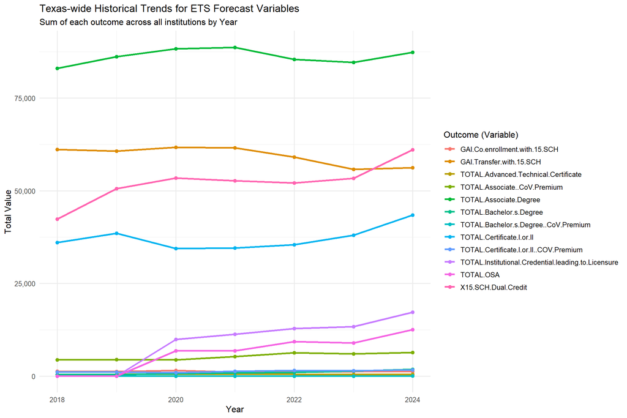

```r
# Subset tsdata to forecast variables
forecast_vars <- c(
  "X15.SCH.Dual.Credit",
  "GAI.Transfer.with.15.SCH",
  "GAI.Co.enrollment.with.15.SCH",
  "TOTAL.Institutional.Credential.leading.to.Licensure",
  "TOTAL.OSA",
  "TOTAL.Certificate.I.or.II",
  "TOTAL.Advanced.Technical.Certificate",
  "TOTAL.Associate.Degree",
  "TOTAL.Bachelor.s.Degree",
  "TOTAL.Certificate.I.or.II..COV.Premium",
  "TOTAL.Associate..CoV.Premium",
  "TOTAL.Bachelor.s.Degree..CoV.Premium"
)

# Aggregate data Texas-wide by Year
tx_hist <- tsdata %>%
  as_tibble() %>%               # convert tsibble to plain tibble
  select(Year, all_of(forecast_vars)) %>%
  pivot_longer(
    cols = -Year,
    names_to = "Variable",
    values_to = "Value"
  ) %>%
  group_by(Year, Variable) %>%
  summarise(Total = sum(Value, na.rm = TRUE), .groups = "drop")

# Create grouping for small vs large outcomes (control Y axis)
tx_hist <- tx_hist %>%
  mutate(SizeGroup = if_else(Total < 20000, "Below 20,000", "20,000 and Above"))

# Plot historical trends - overall graph
ggplot(tx_hist, aes(x = Year, y = Total, color = Variable)) +
  geom_line(size = 1.1) +
  geom_point(size = 2) +
  scale_y_continuous(labels = scales::comma) +
  labs(
    title = "Texas-wide Historical Trends for ETS Forecast Variables",
    subtitle = "Sum of each outcome across all institutions by Year",
    x = "Year",
    y = "Total Value",
    color = "Outcome (Variable)"
  ) +
  theme_minimal(base_size = 12) +
  theme(legend.position = "right")
```

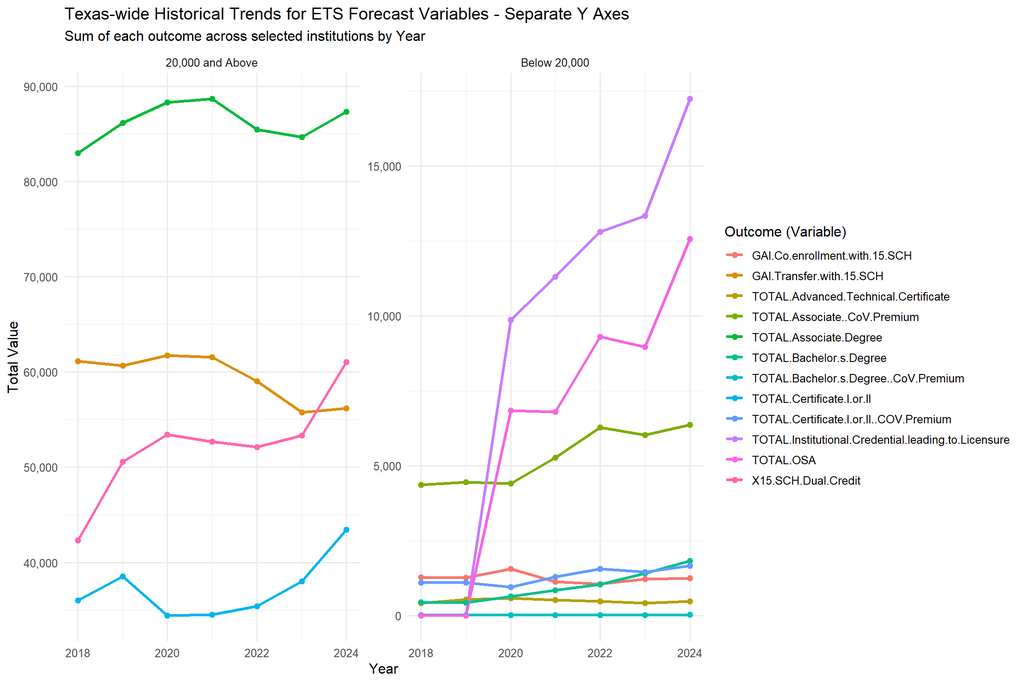

```r
# Plot historical trends - with facets for the two size groups
ggplot(tx_hist, aes(x = Year, y = Total, color = Variable)) +
  geom_line(size = 1.1) +
  geom_point(size = 2) +
  scale_y_continuous(labels = scales::comma) +
  labs(
    title = "Texas-wide Historical Trends for ETS Forecast Variables - Separate Y Axes",
    subtitle = "Sum of each outcome across selected institutions by Year",
    x = "Year",
    y = "Total Value",
    color = "Outcome (Variable)"
  ) +
  facet_wrap(~SizeGroup, scales = "free_y") +
  theme_minimal(base_size = 12) +
  theme(legend.position = "right")
```

## 5.9 ETS Forecast Run

```r
# Safe run wrapper for ETS forecast pipeline
safe_run <- safely(ets_forecast_pipeline)

# Run ETS forecast pipeline for each variable (using forecast_vars object created above)
results <- map(forecast_vars, ~safe_run(tsdata, .x))
```

```
## [INFO] (Forecast) ✅ Completed ETS forecast for variable: X15.SCH.Dual.Credit
```

```
## [INFO] (Forecast) ✅ Completed ETS forecast for variable: GAI.Transfer.with.15.SCH
```

```
## [INFO] (Forecast) ✅ Completed ETS forecast for variable: GAI.Co.enrollment.with.15.SCH
```

```
## [INFO] (Forecast) ℹ️ Excluded 2018–2019 data from ETS model for TOTAL.Institutional.Credential.leading.to.Licensure per missing data
```

```
## [INFO] (Forecast) ✅ Completed ETS forecast for variable: TOTAL.Institutional.Credential.leading.to.Licensure
```

```
## [INFO] (Forecast) ℹ️ Excluded 2018–2019 data from ETS model for TOTAL.OSA per missing data
```

```
## [INFO] (Forecast) ✅ Completed ETS forecast for variable: TOTAL.OSA
```

```
## [INFO] (Forecast) ✅ Completed ETS forecast for variable: TOTAL.Certificate.I.or.II
```

```
## [INFO] (Forecast) ✅ Completed ETS forecast for variable: TOTAL.Advanced.Technical.Certificate
```

```
## [INFO] (Forecast) ✅ Completed ETS forecast for variable: TOTAL.Associate.Degree
```

```
## [INFO] (Forecast) ✅ Completed ETS forecast for variable: TOTAL.Bachelor.s.Degree
```

```
## [INFO] (Forecast) ✅ Completed ETS forecast for variable: TOTAL.Certificate.I.or.II..COV.Premium
```

```
## [INFO] (Forecast) ✅ Completed ETS forecast for variable: TOTAL.Associate..CoV.Premium
```

```
## [INFO] (Forecast) ✅ Completed ETS forecast for variable: TOTAL.Bachelor.s.Degree..CoV.Premium
```

```r
# Identify any failures
failed_vars <- forecast_vars[map_lgl(results, ~!is.null(.x$error))]

if(length(failed_vars)>0){
  log_qc(paste("❌ The following variables failed:", paste(failed_vars, collapse=", ")), "WARN", "Forecast")
} else {
  log_qc("✅ All variables successfully forecasted!", "INFO", "Forecast")
}
```

```
## [INFO] (Forecast) ✅ All variables successfully forecasted!
```

## 5.10 Check for Presence of Additional ETS Models

```r
# Collect all model types from the model summary files
model_files <- list.files("ets-models", pattern = "-model.xlsx$", full.names = TRUE)
all_models <- map_df(model_files, read.xlsx)

# Get unique ETS model types
unique_models <- unique(all_models$ETS_text)

# Allowed models
accounted_for <- c("ETS(M,N,N)", "ETS(A,N,N)")

# QC: Check for any unaccounted for models
unaccounted_for <- setdiff(unique_models, accounted_for)

if (length(unaccounted_for) == 0) {
  msg <- sprintf(
    "✅ Only allowed ETS models detected: %s.",
    paste(accounted_for, collapse = ", "))
  log_qc(msg, "INFO", "ETS Model QC")
} else {
  msg <- sprintf(
    "❌ QC FAIL: Unaccounted for ETS models detected: %s. Accounted for models are: %s.",
    paste(unaccounted_for, collapse = ", "),
    paste(accounted_for, collapse = ", "))
  log_qc(msg, "FAIL", "ETS Model QC")
  stop(msg)
}
```

```
## [INFO] (ETS Model QC) ✅ Only allowed ETS models detected: ETS(M,N,N), ETS(A,N,N).
```

## 5.11 Merge ETS Forecast Outputs

- 50 rows expected (one per institution)
- 16 columns expected (FICE, Institution, Year, Type + 12 ETS forecast vars)

```r
# Get all XLSX files from the ets-forecasts output folder
# Only include files with starting characters "ETS25-"
xlsx_files <- list.files("ets-forecasts",
                         pattern = "^ETS25-.*-forecast\\.xlsx$",
                         full.names = TRUE)

# Read all XLSX files into a list of data frames
df_list <- map(xlsx_files, read.xlsx)

# QC: Check for correct number of forecast files
if(length(df_list) == 12) log_qc("✅ All forecast files found", "INFO", "Merge")
```

```
## [INFO] (Merge) ✅ All forecast files found
```

```r
if(length(df_list) < 12) log_qc("❌ Less than 12 forecast files found", "FAIL", "Merge")
if(length(df_list) < 12) log_qc("❌ Greater than 12 forecast files found", "FAIL", "Merge")

# Inner join all data frames in the list
joined_df <- suppressMessages(reduce(df_list, inner_join))

# QC: Check for correct number of forecast rows (n=50) and columns (n=16) in file merging
if(nrow(joined_df)<50) log_qc("❌ Merged forecast row error", "FAIL", "Merge")
if(ncol(joined_df)!=16) log_qc("❌ Merged forecast column error", "FAIL", "Merge")

# Print row and column counts for debugging
log_qc(paste("ℹ️ Merged forecast rows:", nrow(joined_df)), "INFO", "Merge")
```

```
## [INFO] (Merge) ℹ️ Merged forecast rows: 50
```

```r
log_qc(paste("ℹ️ Merged forecast columns:", ncol(joined_df)), "INFO", "Merge")
```

```
## [INFO] (Merge) ℹ️ Merged forecast columns: 16
```

```r
# Relocate columns to align with correct funding model order
joined_df <- joined_df %>%
  relocate(c(X15.SCH.Dual.Credit, GAI.Transfer.with.15.SCH), .before = GAI.Co.enrollment.with.15.SCH) %>%
  relocate(c(TOTAL.Institutional.Credential.leading.to.Licensure, TOTAL.OSA), .after = GAI.Co.enrollment.with.15.SCH) %>%
  relocate(TOTAL.Certificate.I.or.II, .before = TOTAL.Advanced.Technical.Certificate) %>%
  relocate(TOTAL.Associate..CoV.Premium, .after = TOTAL.Bachelor.s.Degree) %>%
  relocate(TOTAL.Certificate.I.or.II..COV.Premium, .before = TOTAL.Associate..CoV.Premium)
```

## 5.12 Check for Outliers in ETS Forecasts

```r
# Read historical data
raw_data <- read.xlsx(params$merged_data) %>%
  mutate(Type = "Historical") %>%
  relocate("Type", .after = Year) %>%
  mutate(across(-c(FICE, Institution, Type), as.numeric))

# Run QC check (historical vs. forecasts)
outliers <- check_forecast_outliers(
  historical = raw_data,
  forecast   = joined_df,
  abs_threshold = 20,
  pct_threshold = 0.25,
  min_val = 50
)
```

```
## [INFO] (Outlier QC) ℹ️ 266 rows removed because both Forecast and 2024 < 50 (min_val).
```

```
## [WARN] (Outlier QC) ℹ️ 41 out of 600 ETS forecasts (6.8%) exceed both 20 absolute and 25% relative difference from 2024 values.
```

```r
# QC: Create table for outlier information, including Value_2024, Forecast, abs_diff, and pct_diff
if (exists("outliers") && nrow(outliers) > 0) {
  outlier_table <- outliers %>%
    select(FICE, Institution, Variable, Value_2024, Forecast, abs_diff, pct_diff) %>%
  mutate(
    pct_diff = round(pct_diff * 100, 0),
    pct_diff = paste0(pct_diff, "%")) %>%
    arrange(desc(pct_diff))


  # Show top outlier information
  kable(
    head(outlier_table, 20),
    caption = "QC: Top 20 Outliers by Outlier Percentage Difference",
    align = c("l", "l", "l", "c", "c", "c", "c") # left for cols 1-3, center for 4-7
  )
} else {
  log_qc("ℹ️ No outliers detected in forecast vs. 2024 comparison.", "INFO", "Outlier QC")
}
```

QC: Top 20 Outliers by Outlier Percentage Difference

| FICE | Institution | Variable | Value_2024 | Forecast | abs_diff | pct_diff |
| --- | --- | --- | --- | --- | --- | --- |
| 003572 | Trinity Valley Community College | TOTAL.OSA | 954 | 99 | 855 | 90% |
| 003601 | Paris Junior College | TOTAL.OSA | 236 | 47 | 189 | 80% |
| 003627 | Temple College | TOTAL.OSA | 135 | 27 | 108 | 80% |
| 003668 | Wharton County Junior College | TOTAL.OSA | 384 | 78 | 306 | 80% |
| 029137 | San Jacinto Community College | TOTAL.Advanced.Technical.Certificate | 63 | 15 | 48 | 76% |
| 003546 | Coastal Bend College | TOTAL.OSA | 427 | 109 | 318 | 74% |
| 003600 | Panola College | TOTAL.OSA | 169 | 46 | 123 | 73% |
| 003628 | Texarkana College | TOTAL.OSA | 288 | 80 | 208 | 72% |
| 009331 | Dallas College District | TOTAL.OSA | 1020 | 286 | 734 | 72% |
| 003570 | Grayson College | TOTAL.Institutional.Credential.leading.to.Licensure | 59 | 99 | 40 | 68% |
| 003627 | Temple College | TOTAL.Institutional.Credential.leading.to.Licensure | 135 | 222 | 87 | 64% |
| 010060 | Vernon College | TOTAL.OSA | 314 | 144 | 170 | 54% |
| 003600 | Panola College | TOTAL.Institutional.Credential.leading.to.Licensure | 719 | 336 | 383 | 53% |
| 003643 | Texas Southmost College | TOTAL.OSA | 52 | 79 | 27 | 52% |
| 003668 | Wharton County Junior College | TOTAL.Institutional.Credential.leading.to.Licensure | 122 | 181 | 59 | 48% |
| 003546 | Coastal Bend College | TOTAL.Institutional.Credential.leading.to.Licensure | 186 | 98 | 88 | 47% |
| 003558 | North Central Texas College | TOTAL.OSA | 141 | 75 | 66 | 47% |
| 009797 | Midland College | TOTAL.Institutional.Credential.leading.to.Licensure | 569 | 302 | 267 | 47% |
| 010060 | Vernon College | TOTAL.Institutional.Credential.leading.to.Licensure | 237 | 128 | 109 | 46% |
| 003568 | Frank Phillips College | TOTAL.Institutional.Credential.leading.to.Licensure | 208 | 115 | 93 | 45% |

```r
# Export outliers for review
if (nrow(outliers) > 0) {
  write.xlsx(outliers,
             file = "final-forecasts/fy25-official-forecast-outliers.xlsx",
             overwrite = TRUE)
  log_qc("✅ Exported outliers to final-forecasts/fy25-official-forecast-outliers.xlsx", "INFO", "Outlier QC")
} else {
  log_qc("ℹ️ No forecast outliers exported (none detected).", "INFO", "Outlier QC")
}
```

```
## [INFO] (Outlier QC) ✅ Exported outliers to final-forecasts/fy25-official-forecast-outliers.xlsx
```

## 5.13 Export Final ETS Forecast File

```r
# Add ETS forecast data to raw data
data_ets <- raw_data %>%
  add_row(joined_df)

# Change NAs to blanks
data_ets[is.na(data_ets)] <- ""

# Export forecast output
write.xlsx(data_ets, file = "ets-forecasts/fy25-official-ets-forecasts.xlsx", overwrite = TRUE)

# Forecast output QC
if (!file.exists("ets-forecasts/fy25-official-ets-forecasts.xlsx")) {
  log_qc("❌ Final ETS forecast file not written", "FAIL", step = "Export")
} else {
  log_qc("✅ Final ETS forecast file successfully written: ets-forecasts/fy25-official-ets-forecasts.xlsx", "INFO", step = "Export")
}
```

```
## [INFO] (Export) ✅ Final ETS forecast file successfully written: ets-forecasts/fy25-official-ets-forecasts.xlsx
```

```r
# Also save as tibble for use in parent RMD
fc_ets <- data_ets
```

## 5.14 Visualize ETS Forecast Trends

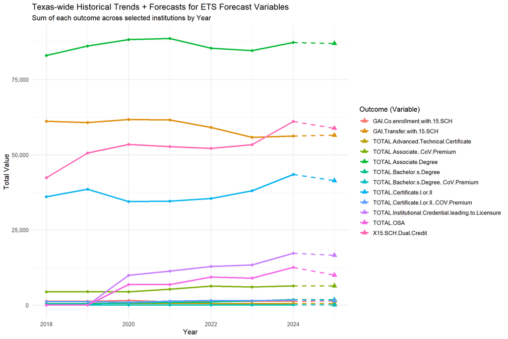

```r
# Combine historical and forecast data for trend line
tx_hist_forecast <- data_ets %>%
  as_tibble() %>%
  select(Year, all_of(forecast_vars)) %>%
  mutate(across(-Year, as.numeric)) %>%  # force numeric
  pivot_longer(
    cols = -Year,
    names_to = "Variable",
    values_to = "Value"
  ) %>%
  group_by(Year, Variable) %>%
  summarise(Total = sum(Value, na.rm = TRUE), .groups = "drop") %>%
  mutate(DataType = if_else(Year <= 2024, "Historical", "Forecast"))

# classify each variable based on its maximum total
var_size <- tx_hist_forecast %>%
  group_by(Variable) %>%
  summarise(MaxTotal = max(Total, na.rm = TRUE), .groups = "drop") %>%
  mutate(SizeGroup = if_else(MaxTotal < 20000, "Below 20,000", "20,000 and Above"))

tx_hist_forecast <- tx_hist_forecast %>%
  left_join(var_size %>% select(Variable, SizeGroup), by = "Variable")

# Create segments for 2024 -> 2025 for each variable
segment_data <- tx_hist_forecast %>%
  filter(Year %in% c(2024, 2025)) %>%
  select(Year, Variable, Total, SizeGroup) %>%
  pivot_wider(names_from = Year, values_from = Total) %>%
  filter(!is.na(`2024`) & !is.na(`2025`)) %>%
  rename(Actual_2024 = `2024`, Forecast_2025 = `2025`)

# Plot
ggplot() +
  # Historical line
  geom_line(data = tx_hist_forecast %>% filter(DataType == "Historical"),
            aes(x = Year, y = Total, color = Variable), size = 1.1) +
  geom_point(data = tx_hist_forecast %>% filter(DataType == "Historical"),
             aes(x = Year, y = Total, color = Variable), size = 2, shape = 16) + # circles

  # Dashed segments 2024 -> 2025
  geom_segment(data = segment_data,
               aes(x = 2024, xend = 2025, y = Actual_2024, yend = Forecast_2025, color = Variable),
               linetype = "dashed", size = 1) +

  # Forecast points
  geom_point(data = tx_hist_forecast %>% filter(DataType == "Forecast"),
             aes(x = Year, y = Total, color = Variable), size = 3, shape = 17) + # triangles

  scale_y_continuous(labels = scales::comma) +
  labs(
    title = "Texas-wide Historical Trends + Forecasts for ETS Forecast Variables",
    subtitle = "Sum of each outcome across selected institutions by Year",
    x = "Year",
    y = "Total Value",
    color = "Outcome (Variable)"
  ) +
  theme_minimal(base_size = 12) +
  theme(legend.position = "right")
```

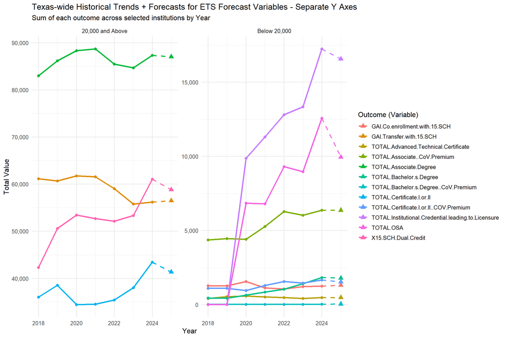

```r
# Plot with facets by size group
ggplot() +
  # Historical line
  geom_line(data = tx_hist_forecast %>% filter(DataType == "Historical"),
            aes(x = Year, y = Total, color = Variable), size = 1.1) +
  geom_point(data = tx_hist_forecast %>% filter(DataType == "Historical"),
             aes(x = Year, y = Total, color = Variable), size = 2, shape = 16) + # circles

  # Dashed segments 2024 -> 2025
  geom_segment(data = segment_data,
               aes(x = 2024, xend = 2025, y = Actual_2024, yend = Forecast_2025, color = Variable),
               linetype = "dashed", size = 1) +

  # Forecast points
  geom_point(data = tx_hist_forecast %>% filter(DataType == "Forecast"),
             aes(x = Year, y = Total, color = Variable), size = 3, shape = 17) + # triangles

  scale_y_continuous(labels = scales::comma) +
  labs(
    title = "Texas-wide Historical Trends + Forecasts for ETS Forecast Variables - Separate Y Axes",
    subtitle = "Sum of each outcome across selected institutions by Year",
    x = "Year",
    y = "Total Value",
    color = "Outcome (Variable)"
  ) +
  facet_wrap(~SizeGroup, scales = "free_y") +   # split into 2 plots
  theme_minimal(base_size = 12) +
  theme(legend.position = "right")
```

## 5.15 Check ETS Forecasts % Change from 2024 to 2025

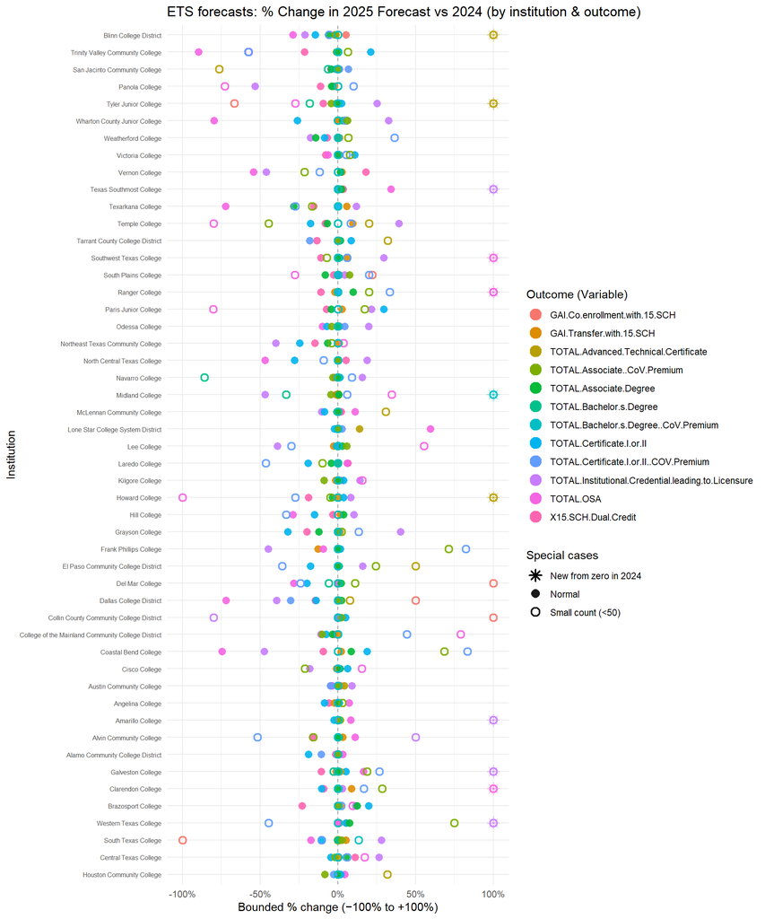

```r
# Build long-format comparison table for ETS
# Use same vars object as created earlier (forecast_vars)
# Subset 2024 historical
hist_2024 <- raw_data %>%
  filter(Year == 2024) %>%
  select(FICE, Institution, all_of(forecast_vars)) %>%
  pivot_longer(-c(FICE, Institution), names_to = "Variable", values_to = "Value_2024")

# Subset 2025 ETS forecasts
fcst_2025 <- joined_df %>%
  filter(Year == 2025) %>%
  select(FICE, Institution, all_of(forecast_vars)) %>%
  pivot_longer(-c(FICE, Institution), names_to = "Variable", values_to = "Forecast")

# Join into comp_long
comp_long_ets <- left_join(fcst_2025, hist_2024, by = c("FICE", "Institution", "Variable"))

# Build delta (change from 2024 actual to 2025 forecast) dataframe
delta_df <- comp_long_ets %>%
  mutate(
    abs_diff = Forecast - coalesce(Value_2024, 0),
    pct_change_raw = if_else(!is.na(Value_2024) & Value_2024 != 0,
                             100 * (Forecast - Value_2024) / abs(Value_2024),
                             NA_real_),
    pct_change_bounded = 100 * (Forecast - coalesce(Value_2024, 0)) /
      pmax(abs(coalesce(Value_2024, 0)), abs(Forecast), 1),
    flag_new_from_zero = (!is.na(Value_2024) & Value_2024 == 0 & Forecast > 0),
    small_base = (coalesce(Value_2024, 0) < 50 | coalesce(Forecast, 0) < 50) # flag small bases
  )

# Order institutions by median absolute difference
inst_order <- delta_df %>%
  group_by(Institution) %>%
  summarize(med_abs = median(abs_diff, na.rm = TRUE)) %>%
  arrange(desc(med_abs)) %>%
  pull(Institution)

# Plot
ggplot(delta_df, aes(x = pct_change_bounded,
                     y = factor(Institution, levels = inst_order))) +
  # reference line at 0% change
  geom_vline(xintercept = 0, linetype = "dashed", color = "grey60") +

  # main points (uniform size)
  geom_point(aes(color = Variable,
                 shape = if_else(small_base, "small", "normal")),
             size = 2.5, alpha = 0.9, stroke = 1.2) +

  # star marker for new-from-zero cases
  geom_point(data = delta_df %>% filter(flag_new_from_zero),
             aes(x = pct_change_bounded,
                 y = factor(Institution, levels = inst_order),
                 color = Variable,
                 shape = "new_from_zero"),
             size = 3.5, inherit.aes = FALSE) +

  # axis scaling
  scale_x_continuous(labels = function(x) paste0(x, "%"),
                     limits = c(-100, 100)) +

  # shape legend (normal, hollow, star)
  scale_shape_manual(
    values = c("normal" = 16, "small" = 1, "new_from_zero" = 8),
    labels = c("normal" = "Normal",
               "small" = "Small count (<50)",
               "new_from_zero" = "New from zero in 2024"),
    name = "Special cases"
  ) +

  # labels
  labs(
    title = "ETS forecasts: % Change in 2025 Forecast vs 2024 (by institution & outcome)",
    x = "Bounded % change (−100% to +100%)",
    y = "Institution",
    color = "Outcome (Variable)"
  ) +

  # legend cleanup
  guides(
    color = guide_legend(override.aes = list(size = 4, alpha = 1)),
    shape = guide_legend(override.aes = list(size = 3, stroke = 1.2))
  ) +

  theme_minimal(base_size = 11) +
  theme(axis.text.y = element_text(size = 6),
        legend.position = "right")
```

## 5.16 Export QC Log Summary for ETS Forecasting

```r
# Output QC Log
summarize_qc(qc_events, Final = TRUE)
```

```
## QC Run Summary (Final): INFO 32 | WARN 1 | FAIL 0 | Runtime: 31.9 seconds
```

```
##  - [WARN] (Outlier QC) ℹ️ 41 out of 600 ETS forecasts (6.8%) exceed both 20 absolute and 25% relative difference from 2024 values.
```

# 6 Run PCT Forecast

## 6.1 PCT Document Summary

This document applies the **Percentage-based (PCT) forecasting method**, which uses each institution’s **average historical subgroup percentages** to project how forecast credentials (from the ETS method) will be distributed across subgroups. Specifically, it estimates the percentage of credentials awarded in **high-demand fields** and to students who are **academically disadvantaged, economically disadvantaged, and/or adult learners**.

First, the **annual subgroup percentages** are calculated, which define the percentage of total credentials conferred to each subgroup in a given year. Second, the **average historical subgroup percentages** are calculated, which define the multi-year average of the annual subgroup percentages for each relevant subgroup.

The outputs include intermediate, annual historical averages saved in the pct-averages/ folder and final combined forecast files saved in the final-forecasts/ folder. The combined forecast output integrates both ETS and PCT results into a single data frame ready for input into the community college funding model.

## 6.2 Global Setup

```r
knitr::opts_chunk$set(echo = TRUE, warning = FALSE, message = TRUE)

library(openxlsx)
library(purrr)
library(tidyverse)
library(ggplot2)
library(knitr)
library(kableExtra)
```

## 6.3 Quality Control Functions:

- log_qc
- summarize_qc
- check_forecast_outliers
- check_required_vars

```r
# QC global objects
qc_logfile <- file.path("logs", paste0("qc_pct_", format(Sys.time(), "%Y%m%d_%H%M"), ".txt"))
qc_events <- list()
qc_start_time <- Sys.time()

# Centralized Quality Control (QC) Log
log_qc <- function(msg, level = c("INFO", "WARN", "FAIL"), step = NULL, logfile = qc_logfile) {
  # Create log message with time stamp and process level
  level <- match.arg(level)
  timestamp <- format(Sys.time(), "%Y-%m-%d %H:%M")
  prefix <- paste0("[",level,"]")
  if (!is.null(step)) {
    prefix <- paste0(prefix, " (", step, ")")
  }
  full_msg <- paste(prefix, msg)

  # Wrap to console width
  wrapped_msg <- paste(strwrap(full_msg, width = getOption("width")), collapse = "\n")

  # Save to global qc_events
  qc_events[[length(qc_events) + 1]] <<- list(
    level = level, step = step, msg = msg, timestamp = timestamp)

  # Print 3 types of QC output to console
  if (level == "INFO") message(full_msg)
  if (level == "WARN") warning(full_msg, call. = FALSE)
  if (level == "FAIL") {
    message(full_msg)
    # Show summary up to this point before stopping
    summarize_qc(qc_events, Final = FALSE, start_time = qc_start_time)
    stop(full_msg, call. = FALSE)
  }

  # Append console output to logfile
  cat(full_msg, file = logfile, append = TRUE, sep = "\n")
}

# Print Initial message
log_qc("ℹ️ QC system initialized for PCT forecasting", "INFO", "Init")
```

```
## [INFO] (Init) ℹ️ QC system initialized for PCT forecasting
```

```r
# Summarize QC results
summarize_qc <- function(events, Final = TRUE, logfile = qc_logfile, start_time = qc_start_time) {
  if (length(events) == 0) {
    msg <- "No QC events logged."
    message(msg)
    cat(msg, file = logfile, append = TRUE, sep = "\n")
    return(invisible(NULL))
  }

  # Count events by level (always INFO, WARN, FAIL)
  levels <- c("INFO", "WARN", "FAIL")
  counts <- table(factor(vapply(events, function(e) e$level, character(1)), levels = levels))

  # Calculate run time
  runtime <- as.numeric(difftime(Sys.time(), start_time, units = "secs"))
  runtime_fmt <- if (runtime < 60) sprintf("%.1f seconds", runtime) else if (runtime < 3600) sprintf("%.1f minutes", runtime/60) else sprintf("%.2f hours", runtime/3600)

  # Build QC summary line
  summary_msg <- paste(
    if (Final) "QC Run Summary (Final):" else "QC Run Summary (so far):",
    paste(names(counts), counts, collapse = " | "),
    "| Runtime:", runtime_fmt)

  # Print QC summary lines in log
  message(summary_msg)
  cat(summary_msg, file = logfile, append = TRUE, sep = "\n")

  # Show WARN/FAIL details
  warn_fail <- Filter(function(e) e$level %in% c("WARN", "FAIL"), events)
  if (length(warn_fail) > 0) {
    msg <- "Warnings/Failures:"
    message(msg)
    cat(msg, file = logfile, append = TRUE, sep = "\n")
    for (e in warn_fail) {
      detail <- paste(" - [", e$level, "] (", e$step, ") ", e$msg, sep = "")
      message(detail)
      cat(detail, file = logfile, append = TRUE, sep = "\n")
    }
  } else {
    msg <- "No warnings or failures. ✅ All checks passed!"
    message(msg)
    cat(msg, file = logfile, append = TRUE, sep = "\n")
  }
}

# Outlier QC function
# Hybrid rule = absolute value greater than threshold AND percent difference greater than threshold
# Comparing 2024 -> 2025
# NOTE, 3750 TOTAL forecasts = 75 forecasts for 50 colleges;
# This QC includes 12 ETS forecasts and 63 PCT forecasts for determining overall outlier count.

check_forecast_outliers <- function(historical,
                                    forecast,
                                    abs_threshold = 20,
                                    pct_threshold = 0.25,
                                    min_val = 50,
                                    logfun = log_qc,
                                    export_missing = TRUE) {
  # historical: full historical dataset (contains Year)
  # forecast: full forecast dataset (contains Year)
  # abs_threshold: absolute difference threshold (same units as variables)
  # pct_threshold: relative difference threshold (fraction, e.g. 0.25 = 25%)
  # min_val: require either forecast or historical to be >= min_val for outlier to count
  # logfun: function for logging QC information (log_qc)
  # export_missing: if TRUE, export a diagnostic listing missing (college,variable) comparisons

  # Helper function for WARN messages that prints immediately
  log_warn_immediate <- function(msg) {
    logfun(msg, "WARN", "Outlier QC")
    message(sprintf("[WARN] (Outlier QC) %s", msg))
  }

  # Identify forecast columns (exclude ids/index columns)
  forecast_vars <- setdiff(names(forecast), c("FICE", "Institution", "Year", "Type"))
  if (length(forecast_vars) == 0) {
    logfun("❌ No forecast variables detected (nothing to compare).", "FAIL", "Outlier QC")
    return(tibble())
  }

  # Subset 2024 historicals and 2025 forecasts
  hist_2024 <- historical %>%
    filter(Year == 2024) %>%
    select(FICE, Institution, all_of(forecast_vars))

  fcst_2025 <- forecast %>%
    filter(Year == 2025) %>%
    select(FICE, Institution, all_of(forecast_vars))

  # Pivot to long for easy comparison
  hist_long <- hist_2024 %>%
    pivot_longer(cols = -c(FICE, Institution), names_to = "Variable", values_to = "Value_2024")

  fc_long <- fcst_2025 %>%
    pivot_longer(cols = -c(FICE, Institution), names_to = "Variable", values_to = "Forecast")

  # Join forecasts to historicals (left join on forecasts)
  comp <- left_join(fc_long, hist_long, by = c("FICE", "Institution", "Variable"))

  # Robust numeric conversion & diffs
  comp <- comp %>%
    mutate(
      Forecast_num = suppressWarnings(as.numeric(Forecast)),
      Value2024_num = suppressWarnings(as.numeric(Value_2024)),
      # compute diffs using numeric versions
      abs_diff = abs(Forecast_num - Value2024_num),
      denom = ifelse(is.na(Value2024_num) | Value2024_num == 0, 1, abs(Value2024_num)),
      pct_diff = pmin(abs_diff / denom, 1.00)  # cap at 100%
    )

  # Diagnostic counts before filtering
  n_before <- nrow(comp)

  # ENFORCE min_val as a hard pre-filter
  # Keep rows only if at least one side is >= min_val (this removes rows where BOTH < min_val)
  comp_filtered <- comp %>%
    filter(!is.na(Forecast_num) & !is.na(Value2024_num)) %>%
    filter(Forecast_num >= min_val | Value2024_num >= min_val)


  n_after_minval <- nrow(comp_filtered)
  n_removed_by_minval <- n_before - n_after_minval

  # Log how many rows were removed by min_val (helpful diagnostic)
  logfun(sprintf("ℹ️ %d rows removed because both Forecast and 2024 < %d (min_val).",
                 n_removed_by_minval, min_val),
         "INFO", "Outlier QC")

  # Apply threshold rule to the (already min_val-filtered) set
  outliers_df <- comp_filtered %>%
    filter(abs_diff > abs_threshold & pct_diff > pct_threshold)

  # Diagnostics: Expected comparisons (institutions * variables) vs actual rows available to compare
  inst_union <- sort(unique(c(unique(fc_long$FICE), unique(hist_long$FICE))))
  expected_total <- length(inst_union) * length(forecast_vars)

  # Use the number of rows actually used for threshold testing (comp_filtered)
  actual_comp_rows <- n_after_minval

  # Percent of outliers relative to actual comparisons used
  outlier_pct <- if (actual_comp_rows > 0) nrow(outliers_df) / actual_comp_rows else 0

  # Compute % outliers relative to the ENTIRE dataset (before any filtering)
  outlier_pct_total <- if (n_before > 0) nrow(outliers_df) / n_before else 0

  # Log the main QC message (WARN if >5% otherwise INFO)
  msg_text <- sprintf(
    "ℹ️ %d out of %d ETS & PCT forecasts (%.1f%%) exceed both %d absolute and %.0f%% relative difference from 2024 values.",
    nrow(outliers_df), n_before, 100 * outlier_pct_total, abs_threshold, 100 * pct_threshold
  )

  if(outlier_pct_total > 0.05) {
    log_warn_immediate(msg_text)   # prints immediately
  } else {
    logfun(msg_text, "INFO", "Outlier QC")  # normal INFO logging
  }

  # If actual comparisons differ from expected, export a small diagnostic and log it
  if (n_before != expected_total) {
    diag_msg <- sprintf(
      "❌ Expected %d comparisons (institutions * vars) but have %d joined rows to compare. Missing: %d.",
      expected_total, n_before, expected_total - n_before)
    logfun(diag_msg, "INFO", "Outlier QC")

    if (export_missing) {
      all_pairs <- expand_grid(FICE = inst_union, Variable = forecast_vars)
      present_pairs <- comp %>% distinct(FICE, Variable)
      missing_pairs <- anti_join(all_pairs, present_pairs, by = c("FICE", "Variable"))
      write.xlsx(missing_pairs, file = "final-forecasts/fy25-official-outlier-missing-diagnostic.xlsx", overwrite = TRUE)
      logfun("✅ Exported missing-comparisons diagnostic to final-forecasts/fy25-official-outlier-missing-diagnostic.xlsx", "INFO", "Outlier QC")
    }
  }

  # Return the outliers in the shape downstream code expects
  out_final <- outliers_df %>%
    transmute(FICE, Institution, Variable, Forecast = Forecast_num, Value_2024 = Value2024_num, abs_diff, pct_diff)

  invisible(out_final)
}

# Function to check that all required variable names exist in a dataset
check_required_vars <- function(data, required_vars, context = "Unknown", stop_on_missing = TRUE) {
  missing_vars <- setdiff(required_vars, names(data))
  if (length(missing_vars) > 0) {
    msg <- paste0(
      "❌ Missing or misspelled variables detected in ", context, ": ",
      paste(missing_vars, collapse = ", ")
    )
    log_qc(msg, "FAIL", context)
    if (stop_on_missing) stop(msg, call. = FALSE)
  } else {
    log_qc(
      paste0("✅ All required variables found for ", context, " (n=", length(required_vars), ")."),
      "INFO", context
    )
  }
}
```